# Aplicação de Hierarchical Risk Parity (HRP) nos Fatores de Risco da Bolsa Brasileira

Arthur Wachslicht

## Fatores de Risco

O NEFIN (Núcleo de Pesquisa em Economia Financeira) disponibiliza séries históricas dos fatores de risco da bolsa brasileira, sendo eles:  
- Rm_minus_Rf -> Fator de mercado  
- SMB -> Tamanho  
- HML -> Valor  
- WML -> Momentum  
- IML -> Liquidez

Através da biblioteca {nefindata} do Fernando Martinelli Ramacciotti, é possível obter essas séries históricas no R.

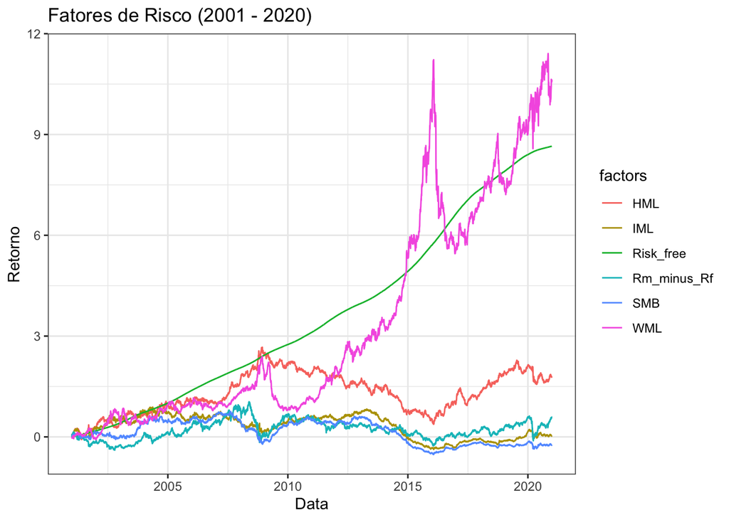

```r
library(nefindata)
library(dplyr)
library(ggplot2)
library(tidyr)

factor_df <- get_risk_factors(factors = "all",
                                         agg = "day")

factor_df %>%
  filter(year <= 2020) %>%
  mutate(date = as.Date(paste(year, month, day, sep = "/"))) %>%
  arrange(date) %>%
  mutate(across(-c("year", "month", "day", "date"), ~ cumprod(1 + .x) - 1)) %>%
  pivot_longer(-c("year", "month", "day", "date"),
               names_to = "factors") %>%
  ggplot(aes(date, value)) +
  geom_line(aes(col = factors))+
  theme_bw()+
  labs(title = "Fatores de Risco (2001 - 2020)",
       x = "Data",
       y = "Retorno")
```

Existe uma discrepância bem grande entre Momentum e os outros fatores, sendo o único que superou o CDI no período.

## Hierarchical Risk Parity

Marcos López de Prado propôs um algoritmo de paridade de risco utilizando Hierarchical Tree Clustering (BUILDING DIVERSIFIED PORTFOLIOS THAT OUTPERFORM OUT-OF-SAMPLE). O algoritmo será usado para alocar os fatores de risco em um portfolio.  
Abaixo, estão as funções que realizam a alocação de pesos através de *Matrix Seriation* e *Recursive Bisection*. As funções foram retiradas do [*r-bloggers*](https://www.r-bloggers.com/2017/05/testing-the-hierarchical-risk-parity-algorithm/).

```r
getIVP <- function(covMat) {
  invDiag <- 1/diag(as.matrix(covMat))
  weights <- invDiag/sum(invDiag)
  return(weights)
}

getClusterVar <- function(covMat, cItems) {
  covMatSlice <- covMat[cItems, cItems]
  weights <- getIVP(covMatSlice)
  cVar <- t(weights) %*% as.matrix(covMatSlice) %*% weights
  return(cVar)
}

getRecBipart <- function(covMat, sortIx) {
  # keeping track of w in the global environment
  assign("w", value = rep(1, ncol(covMat)), envir = .GlobalEnv)
  recurFun(covMat, sortIx)
  return(w)
}

recurFun <- function(covMat, sortIx) {
  subIdx <- 1:trunc(length(sortIx)/2)
  cItems0 <- sortIx[subIdx]
  cItems1 <- sortIx[-subIdx]
  cVar0 <- getClusterVar(covMat, cItems0)
  cVar1 <- getClusterVar(covMat, cItems1)
  alpha <- 1 - cVar0/(cVar0 + cVar1)

  # scoping mechanics using w as a free parameter
  w[cItems0] <<- w[cItems0] * alpha
  w[cItems1] <<- w[cItems1] * (1-alpha)

  if(length(cItems0) > 1) {
    recurFun(covMat, cItems0)
  }
  if(length(cItems1) > 1) {
    recurFun(covMat, cItems1)
  }
}
```

```r
year_train <- seq(2001, 2019)

year_test <- year_train+1

factor_df <- nefindata::get_risk_factors(factors = "all",
                                         agg = "day") %>%
  mutate(date = as.Date(paste(year, month, day, sep = "/")))

#Empty dataframe
returns_df <- data.frame(Rm_minus_Rf = as.numeric(),
                         SMB = as.numeric(),
                         HML = as.numeric(),
                         WML = as.numeric(),
                         IML = as.numeric(),
                         Portfolio = as.numeric()
)
#Empty dataframe
volatility_df <- data.frame(Rm_minus_Rf = as.numeric(),
                            SMB = as.numeric(),
                            HML = as.numeric(),
                            WML = as.numeric(),
                            IML = as.numeric(),
                            Portfolio = as.numeric()
)
```

O *loop* abaixo calcula os retornos e a volatilidade dos fatores de risco e do portifólio usando HRP e os armazena nos dataframes *returns_df* e *volatility_df*.

```r
for (i in 1:length(year_train)) {
  factor_df_train <- factor_df %>%
    filter(year %in% year_train[1:i])

  factor_df_test <- factor_df %>%
    filter(year == year_test[i])


  correlation_matrix_train <- factor_df_train %>%
    select(-c("year", "month", "day", "date", "Risk_free")) %>%
    cor()

  covariance_matrix_train <- factor_df %>%
    select(-c("year", "month", "day", "date", "Risk_free")) %>%
    cov()

  #Hierarchical Cluster Order
  clust_order_train <- hclust(dist(correlation_matrix_train), method = "single")$order

  #Get weights
  weights <- getRecBipart(covariance_matrix_train, clust_order_train)


  final_portfolio <- factor_df_test %>%
    mutate(across(-c("year", "month", "day", "date", "Risk_free"), ~ .x + 1))

  #Atribuindo pesos aos fatores
  final_portfolio$Rm_minus_Rf[1] <- final_portfolio$Rm_minus_Rf[1]*weights[1]
  final_portfolio$SMB[1] <- final_portfolio$SMB[1]*weights[2]
  final_portfolio$HML[1] <- final_portfolio$HML[1] *weights[3]
  final_portfolio$WML[1] <- final_portfolio$WML[1]*weights[4]
  final_portfolio$IML[1] <- final_portfolio$IML[1]*weights[5]

  final_portfolio <- final_portfolio %>%
    mutate(across(-c("year", "month", "day", "date", "Risk_free"), ~ cumprod(.x))) %>%
    mutate(portfolio = Rm_minus_Rf + SMB + HML + WML + IML - 1)

  #Gráfico 2016

  if (year_test[i] == 2018) {

    plot_series <- factor_df_test %>%
      mutate(across(-c("year", "month", "day", "date"), ~ cumprod(1 + .x) - 1)) %>%
      mutate(Portfolio = final_portfolio$portfolio) %>%
      pivot_longer(-c("year", "month", "day", "date"),
                   names_to = "factors") %>%

      ggplot(aes(date, value)) +
      geom_line(aes(col = factors))+
      theme_bw()+
      labs(title = "Fatores de Risco + Portfolio (2018)",
           x = "Data",
           y = "Retorno")

    plot_weights <- data.frame(Peso = weights,
                               Fator = colnames(covariance_matrix_train)) %>%
      ggplot(aes(x = "",
                 y = Peso,
                 fill = Fator))+
      geom_bar(width = 1, stat = "identity")+
      coord_polar("y", start=0)+
      theme_void()+
      labs("Alocação (2018)")




  }


  volatility <- factor_df_test %>%
    mutate(Portfolio = final_portfolio$portfolio) %>%
    mutate(Portfolio = (1+Portfolio)/(1+lag(Portfolio))-1) %>%
    mutate(Portfolio = ifelse(is.na(Portfolio), 0, Portfolio)) %>%
    summarise(across(-c("year", "month", "day", "date", "Risk_free"), ~sd(.x)*sqrt(252)))

  returns <- factor_df_test %>%
    mutate(across(-c("year", "month", "day", "date"), ~ cumprod(1 + .x) - 1)) %>%
    mutate(Portfolio = final_portfolio$portfolio) %>%
    filter(date == max(date)) %>%
    select(-c("year", "month", "day", "Risk_free", "date"))


  returns_df <- returns_df %>%
    add_row(Rm_minus_Rf = returns$Rm_minus_Rf,
            SMB = returns$SMB,
            HML = returns$HML,
            WML = returns$WML,
            IML = returns$IML,
            Portfolio = returns$Portfolio
    )

  volatility_df <- volatility_df %>%
    add_row(Rm_minus_Rf = volatility$Rm_minus_Rf,
            SMB = volatility$SMB,
            HML = volatility$HML,
            WML = volatility$WML,
            IML = volatility$IML,
            Portfolio = volatility$Portfolio)




}
```

Abaixo, alguns gráficos sobre a alocação e os resultados em 2018.

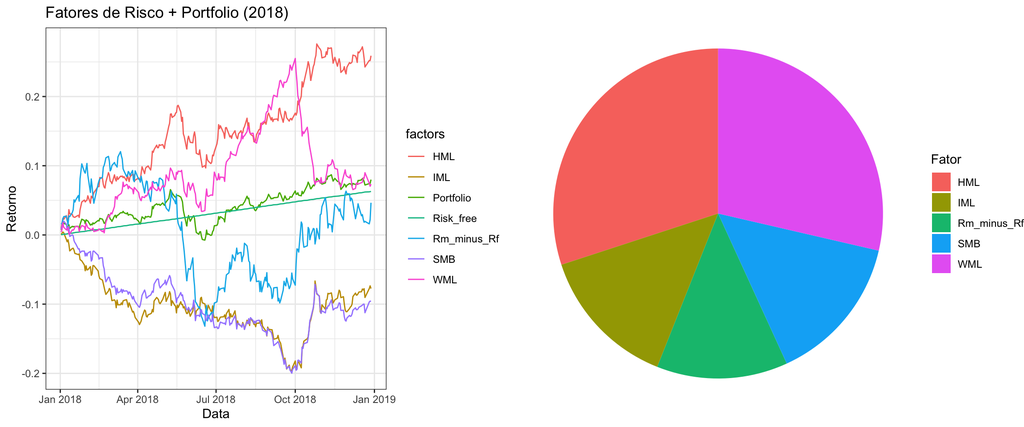

```r
library(gridExtra)
grid.arrange(plot_series, plot_weights, ncol = 2)
```

Calculando a média de retornos e de volatilidade, observa-se que os retornos do portfolio perdem apenas para o fator Momentum e possui a menor volatilidade entre os fatores citados.

```r
returns_df %>% summarise_all(mean)
```

```
##   Rm_minus_Rf        SMB        HML       WML        IML  Portfolio
## 1  0.06040336 0.01443986 0.05589262 0.1769021 0.01065936 0.07875661
```

```r
volatility_df %>% summarise_all(mean)
```

```
##   Rm_minus_Rf       SMB       HML      WML       IML Portfolio
## 1   0.2374784 0.1437963 0.1321334 0.157687 0.1445289 0.0708032
```